# Week 8 Activity: Onset Detection and Autocorrelation

Complete this activity as part of your participation grade. Pending length of the lecture, you will have time in class to work. Everything you need to complete this activity can be found in this week's (or a previous week's) lecture code.

## Onset Detection

Read in the following files below, and normalize.

a) 80sPopDrums.wav  
b) TheBlackKeys_track4.wav (use random 10s from near middle of track)  
c) prelude_cmaj_10s.wav

```python
import numpy as np
import matplotlib.pyplot as plt
plt.rcParams['figure.figsize'] = (8, 4)
from scipy.io.wavfile import read
from scipy import signal
from IPython.display import Audio
import librosa
from librosa import feature, frames_to_time, autocorrelate, clicks, display
from scipy.io.wavfile import read
from collections import Counter

(fs1, x1) = read('../audio/80sPopDrums.wav')
x1 = x1 / np.abs(x1.max())
(fs2, x2) = read('../audio/TheBlackKeys_track4.wav')
x2 = x2[10*fs2:20*fs2]
x2 = x2 / np.abs(x2.max())
(fs3, x3) = read('../audio/prelude_cmaj_10s.wav')
x3 = x3[:,0] # Convert to mon
x3 = x3 / np.abs(x3.max())
```

#### For each of the tracks (start with just one):

1. Compute the energy and RMSE for each track using a frame length of your choice
2. Plot the energy and the RMSE
3. Use one of the energy features to create your novelty function and plot
4. Write a peak picking function to define onsets from your novelty function
5. Based on the plots, estimate what an appropriate 'threshold' would be. Does the threshold change across tracks? If so, what could you do to put them on a similar scale?

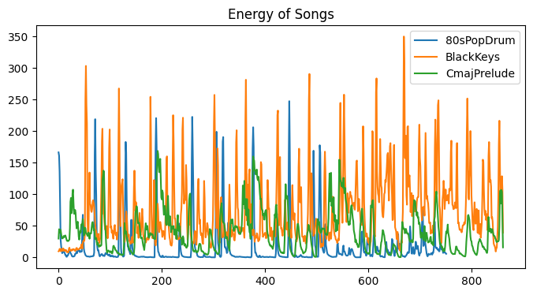

```python
hop_length = 512
frame_length = 1024

energy1 = np.array([
    sum(abs(x1[i:i+frame_length]**2)) for i in range(0, len(x1), hop_length)
])
energy2 = np.array([
    sum(abs(x2[i:i+frame_length]**2)) for i in range(0, len(x2), hop_length)
])
energy3 = np.array([
    sum(abs(x3[i:i+frame_length]**2)) for i in range(0, len(x3), hop_length)
])

plt.plot(energy1)
plt.plot(energy2)
plt.plot(energy3)
plt.title("Energy of Songs")
plt.legend(['80sPopDrum', 'BlackKeys','CmajPrelude'])
```

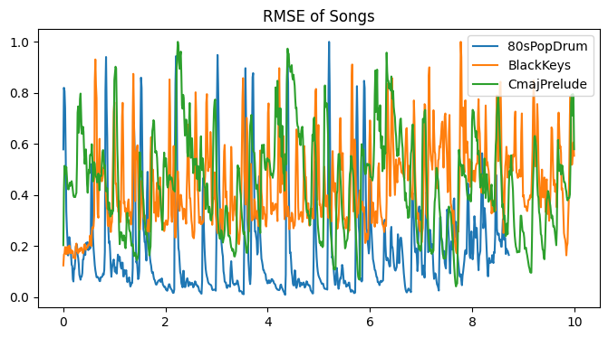

```python
rmse1 = librosa.feature.rms(y = x1, frame_length=frame_length, hop_length=hop_length, center=True)
rmse2 = librosa.feature.rms(y = x2, frame_length=frame_length, hop_length=hop_length, center=True)
rmse3 = librosa.feature.rms(y = x3, frame_length=frame_length, hop_length=hop_length, center=True)
frames1 = range(len(energy1))
frames2 = range(len(energy2))
frames3 = range(len(energy3))
t1 = librosa.frames_to_time(frames1, sr=fs1, hop_length=hop_length)
t2 = librosa.frames_to_time(frames2, sr=fs2, hop_length=hop_length)
t3 = librosa.frames_to_time(frames3, sr=fs3, hop_length=hop_length)

plt.plot(t1, rmse1[0]/rmse1[0].max())
plt.plot(t2, rmse2[0]/rmse2[0].max())
plt.plot(t3, rmse3[0]/rmse3[0].max())
plt.title("RMSE of Songs")
plt.legend(['80sPopDrum', 'BlackKeys','CmajPrelude'])
```

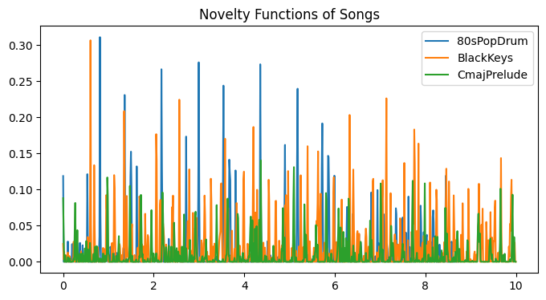

```python
rmse_diff1 = np.diff(rmse1[0])
novelty1 = np.concatenate((rmse_diff1, np.array([0])))
novelty1[novelty1 < 0] = 0
plt.plot(t1, novelty1)
rmse_diff2 = np.diff(rmse2[0])
novelty2 = np.concatenate((rmse_diff2, np.array([0])))
novelty2[novelty2 < 0] = 0
plt.plot(t2, novelty2)
rmse_diff3 = np.diff(rmse3[0])
novelty3 = np.concatenate((rmse_diff3, np.array([0])))
novelty3[novelty3 < 0] = 0
plt.plot(t3, novelty3)
plt.title("Novelty Functions of Songs")
plt.legend(['80sPopDrum', 'BlackKeys','CmajPrelude'])
```

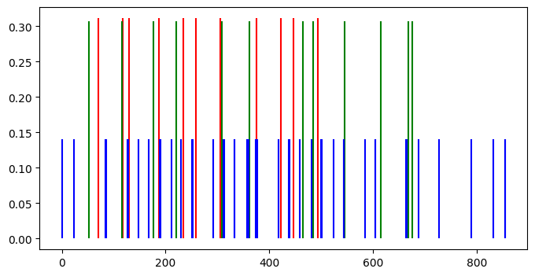

```python
novelty_peaks1 = np.where(novelty1 > 0.15)[0]
novelty_peaks2 = np.where(novelty2 > 0.15)[0]
novelty_peaks3 = np.where(novelty3 > 0.05)[0]

plt.vlines(novelty_peaks1, 0, np.max(novelty1), colors='r')
plt.vlines(novelty_peaks2, 0, np.max(novelty2), colors='g')
plt.vlines(novelty_peaks3, 0, np.max(novelty3), colors='b')

# For drums the threshold should be around 0.15
# For black keys the threshold should be around 0.15
# For prelude the threshold should be around 0.05
```

## Tempo Estimation

Using your novelty functions and detected onsets above, estimate the global tempo of the files using autocorrelation and IOIs.

1. IOI Based Tempo
- Compute Inter-Onset Intervals (IOIs)
- Convert IOIs to BPM
- Create a beat histogram to help you infer tempos
2. Autocorrelation based Tempo
- Compute the autocorrelation of your novelty function
- Convert lag to BPMs (conside perceptual relevance)
- Crate a beat histogram to help you infer tempos

Estimate tempo using librosa.beat.tempo. How do your results compare?

Between autocorrelation and IOIs, which method is most stable? Which is most sensitive to onset errors Do the different files present different behaviors/accuracies?

```python
iois1 = np.diff(t1[1:][novelty_peaks1])
num_counts1 = Counter(iois1)
top_n1 = num_counts1.most_common(3)
print("80s Rock Top Tempos are", 60 / top_n1[0][0], 60 / top_n1[2][0], 60 / top_n1[2][0])

iois2 = np.diff(t2[1:][novelty_peaks2])
num_counts2 = Counter(iois2)
top_n2 = num_counts2.most_common(3)
print("Black Keys Top Tempos are", 60 / top_n2[0][0], 60 / top_n2[2][0], 60 / top_n2[2][0])

iois3 = np.diff(t3[1:][novelty_peaks3])
num_counts3 = Counter(iois3)
top_n3 = num_counts3.most_common(3)
print("Prelude Top Tempos are", 60 / top_n3[0][0], 60 / top_n3[2][0], 60 / top_n3[2][0])
```

```
80s Rock Top Tempos are 109.9567819148936 430.6640625000001 430.6640625000001
Black Keys Top Tempos are 80.74951171874999 117.45383522727278 117.45383522727278
Prelude Top Tempos are 5167.9687499998945 5167.968749999993 5167.968749999993
```

```python
ac1 = librosa.autocorrelate(novelty1)
ac1 = ac1 / ac1.max()
ac1 = ac1[1:]
points1 = np.where(ac1 > 0.3)
points1 = np.array(points1)
t_inc1 = hop_length * points1 /fs1
ts1 = t_inc1[0][2:]
durs1 = ts1[1:] - ts1[:-1]
durs1 = np.round(durs1, 3)
num_counts1 = Counter(durs1)
top_n1 = num_counts1.most_common(3)
print("80s Rock Top Tempos are", 60 / top_n1[0][0], 60 / top_n1[2][0], 60 / top_n1[2][0])

ac2 = librosa.autocorrelate(novelty2)
ac2 = ac2 / ac2.max()
ac2 = ac2[1:]
points2 = np.where(ac2 > 0.3)
points2 = np.array(points2)
t_inc2 = hop_length * points2 /fs2
ts2 = t_inc2[0][2:]
durs2 = ts2[1:] - ts2[:-1]
durs2 = np.round(durs2, 3)
num_counts2 = Counter(durs2)
top_n2 = num_counts2.most_common(3)
print("Black Keys Top Tempos are", 60 / top_n2[0][0], 60 / top_n2[2][0], 60 / top_n2[2][0])

ac3 = librosa.autocorrelate(novelty3)
ac3 = ac3 / ac3.max()
ac3 = ac3[1:]
points3 = np.where(ac3 > 0.3)
points3 = np.array(points3)
t_inc3 = hop_length * points3 /fs3
ts3 = t_inc3[0][2:]
durs3 = ts3[1:] - ts3[:-1]
durs3 = np.round(durs3, 3)
num_counts3 = Counter(durs3)
top_n3 = num_counts3.most_common(3)
print("Prelude Top Tempos are", 60 / top_n3[0][0], 60 / top_n3[2][0], 60 / top_n3[2][0])
```

```
80s Rock Top Tempos are 5000.0 224.7191011235955 224.7191011235955
Black Keys Top Tempos are 5000.0 84.74576271186442 84.74576271186442
Prelude Top Tempos are 5000.0 258.6206896551724 258.6206896551724
```

```python
print(librosa.beat.tempo(x1, sr=fs1))
print(librosa.beat.tempo(x2, sr=fs2))
print(librosa.beat.tempo(x3, sr=fs3))
```

[output not shown]

```
[109.95678191]
[109.95678191]
[126.04801829]
```

[output not shown]

## Extension

Repeat the activities above but change the frame size and hop length. How does that impact your results?